# Project: Investigate a Dataset - TMDB-Movies

- Introduction
- Data Wrangling
- Exploratory Data Analysis
- Conclusions

## Introduction

### Dataset Description

This data set contains information about 10,000+ movies collected from The Movie Database (TMDb), including user ratings and revenue.

#### Columns

**id** The unique ID for each movie

> int (5-417859)

**imdb_id** The unique ID used by IMDB

> str, ex. tt0369610

**popularity** A score generated on lifetime popularity

> float (0.000065-32.985763)

**budget** Budget allocated for the movie

> int (0-425,000,000)

**revenue** Revenue generated by the movie's release

> int (0-2,781,506,000)

**original_title** Original title of the movie

> str, ex. Jurassic World

**cast** Actors and actresses featured in movie separated by "|"

> [str], ex. Chris Pratt|Bryce Dallas|...

**homepage** Movie Website

> str, ex. `http://www.jurassicworld.com/`

**director** Movie director

> str, ex. Colin Treverrow

**tagline** Short tagline for the movie

> str, ex. The park is open.

**keywords** Keywords to search for movie separated by "|"

> [str], ex. monster|dna|...

**overview** Summary of the movie

> str

**runtime** Length of movie in minutes

> int (0, 900)

**genres** Movie genres separated by "|"

> [str], ex. Action|Adventure|...

**production_companies** List of Movie's production companies separated by "|"

> [str], ex. Universal Studios|Amblin Entertainment|...

**release_date** Movie's release date

> Date MM/DD/YY

**vote_count** Number of votes for movie

> int (10, 9,767)

**vote_average** Average movie rating from votes

> float (1.5-9.2)

**release_year** Year of release date

> int (1960-2015)

**budget_adj** Adjusted budget

> int (0.000000e+00, 4.250000e+08)

**revenue_adj** Adjusted revenue

> int (0.000000e+00, 2.827124e+09)

### Question for Analysis

1. When did movie homepages become popular?
2. Is there a average votes rating that is an indicator if a movie has a higher chance of being profitable?
3. What are the most common genres?

```python
import numpy as np
import pandas as pd
import seaborn as sns
import matplotlib.pyplot as plt

%matplotlib inline
```

### Functions

```python
def display_lineplot(data, x, y, xlabel, ylabel, title, legend=True):
    """Display a seaborn lineplot

    Arguments:
    ----------
    data - Pandas dataframe to display
    x - x axis variable
    y - y axis variable
    xlabel - label for x axis
    ylabel - label for y axis
    title - title of the plot
    legend - bool if should display legend (default = False)
    """
    if x is not None and y is not None:
        sns.lineplot(data=data, x=x, y=y, legend=legend)
    elif x is None and y is None:
        sns.lineplot(data, legend=legend)
    plt.xlabel(xlabel)
    plt.ylabel(ylabel)
    plt.title(title);
```

## Data Wrangling

> **Tip**: In this section of the report, you will load in the data, check for cleanliness, and then trim and clean your dataset for analysis. Make sure that you **document your data cleaning steps in mark-down cells precisely and justify your cleaning decisions.**

### Assessing the Data

Load the data into a pandas dataframe

```python
df = pd.read_csv('tmdb-movies.csv')
```

Find the shape of the data

```python
df.shape
```

```
(10866, 21)
```

View the column names, their datatypes, and check for null values

```python
df.info()
```

```
<class 'pandas.core.frame.DataFrame'>
RangeIndex: 10866 entries, 0 to 10865
Data columns (total 21 columns):
 #   Column                Non-Null Count  Dtype
---  ------                --------------  -----
 0   id                    10866 non-null  int64
 1   imdb_id               10856 non-null  object
 2   popularity            10866 non-null  float64
 3   budget                10866 non-null  int64
 4   revenue               10866 non-null  int64
 5   original_title        10866 non-null  object
 6   cast                  10790 non-null  object
 7   homepage              2936 non-null   object
 8   director              10822 non-null  object
 9   tagline               8042 non-null   object
 10  keywords              9373 non-null   object
 11  overview              10862 non-null  object
 12  runtime               10866 non-null  int64
 13  genres                10843 non-null  object
 14  production_companies  9836 non-null   object
 15  release_date          10866 non-null  object
 16  vote_count            10866 non-null  int64
 17  vote_average          10866 non-null  float64
 18  release_year          10866 non-null  int64
 19  budget_adj            10866 non-null  float64
 20  revenue_adj           10866 non-null  float64
dtypes: float64(4), int64(6), object(11)
memory usage: 1.7+ MB
```

Look at first 5 rows of data

```python
df.head()
```

|  | id | imdb_id | popularity | budget | revenue | original_title | cast | homepage | director | tagline | ... | overview | runtime | genres | production_companies | release_date | vote_count | vote_average | release_year | budget_adj | revenue_adj |
| --- | --- | --- | --- | --- | --- | --- | --- | --- | --- | --- | --- | --- | --- | --- | --- | --- | --- | --- | --- | --- | --- |
| 0 | 135397 | tt0369610 | 32.985763 | 150000000 | 1513528810 | Jurassic World | Chris Pratt\|Bryce Dallas Howard\|Irrfan Khan\|Vi... | http://www.jurassicworld.com/ | Colin Trevorrow | The park is open. | ... | Twenty-two years after the events of Jurassic ... | 124 | Action\|Adventure\|Science Fiction\|Thriller | Universal Studios\|Amblin Entertainment\|Legenda... | 6/9/15 | 5562 | 6.5 | 2015 | 1.379999e+08 | 1.392446e+09 |
| 1 | 76341 | tt1392190 | 28.419936 | 150000000 | 378436354 | Mad Max: Fury Road | Tom Hardy\|Charlize Theron\|Hugh Keays-Byrne\|Nic... | http://www.madmaxmovie.com/ | George Miller | What a Lovely Day. | ... | An apocalyptic story set in the furthest reach... | 120 | Action\|Adventure\|Science Fiction\|Thriller | Village Roadshow Pictures\|Kennedy Miller Produ... | 5/13/15 | 6185 | 7.1 | 2015 | 1.379999e+08 | 3.481613e+08 |
| 2 | 262500 | tt2908446 | 13.112507 | 110000000 | 295238201 | Insurgent | Shailene Woodley\|Theo James\|Kate Winslet\|Ansel... | http://www.thedivergentseries.movie/#insurgent | Robert Schwentke | One Choice Can Destroy You | ... | Beatrice Prior must confront her inner demons ... | 119 | Adventure\|Science Fiction\|Thriller | Summit Entertainment\|Mandeville Films\|Red Wago... | 3/18/15 | 2480 | 6.3 | 2015 | 1.012000e+08 | 2.716190e+08 |
| 3 | 140607 | tt2488496 | 11.173104 | 200000000 | 2068178225 | Star Wars: The Force Awakens | Harrison Ford\|Mark Hamill\|Carrie Fisher\|Adam D... | http://www.starwars.com/films/star-wars-episod... | J.J. Abrams | Every generation has a story. | ... | Thirty years after defeating the Galactic Empi... | 136 | Action\|Adventure\|Science Fiction\|Fantasy | Lucasfilm\|Truenorth Productions\|Bad Robot | 12/15/15 | 5292 | 7.5 | 2015 | 1.839999e+08 | 1.902723e+09 |
| 4 | 168259 | tt2820852 | 9.335014 | 190000000 | 1506249360 | Furious 7 | Vin Diesel\|Paul Walker\|Jason Statham\|Michelle ... | http://www.furious7.com/ | James Wan | Vengeance Hits Home | ... | Deckard Shaw seeks revenge against Dominic Tor... | 137 | Action\|Crime\|Thriller | Universal Pictures\|Original Film\|Media Rights ... | 4/1/15 | 2947 | 7.3 | 2015 | 1.747999e+08 | 1.385749e+09 |

5 rows × 21 columns

Look at last 3 rows of data

```python
df.tail(3)
```

|  | id | imdb_id | popularity | budget | revenue | original_title | cast | homepage | director | tagline | ... | overview | runtime | genres | production_companies | release_date | vote_count | vote_average | release_year | budget_adj | revenue_adj |
| --- | --- | --- | --- | --- | --- | --- | --- | --- | --- | --- | --- | --- | --- | --- | --- | --- | --- | --- | --- | --- | --- |
| 10863 | 39768 | tt0060161 | 0.065141 | 0 | 0 | Beregis Avtomobilya | Innokentiy Smoktunovskiy\|Oleg Efremov\|Georgi Z... | NaN | Eldar Ryazanov | NaN | ... | An insurance agent who moonlights as a carthie... | 94 | Mystery\|Comedy | Mosfilm | 1/1/66 | 11 | 6.5 | 1966 | 0.000000 | 0.0 |
| 10864 | 21449 | tt0061177 | 0.064317 | 0 | 0 | What's Up, Tiger Lily? | Tatsuya Mihashi\|Akiko Wakabayashi\|Mie Hama\|Joh... | NaN | Woody Allen | WOODY ALLEN STRIKES BACK! | ... | In comic Woody Allen's film debut, he took the... | 80 | Action\|Comedy | Benedict Pictures Corp. | 11/2/66 | 22 | 5.4 | 1966 | 0.000000 | 0.0 |
| 10865 | 22293 | tt0060666 | 0.035919 | 19000 | 0 | Manos: The Hands of Fate | Harold P. Warren\|Tom Neyman\|John Reynolds\|Dian... | NaN | Harold P. Warren | It's Shocking! It's Beyond Your Imagination! | ... | A family gets lost on the road and stumbles up... | 74 | Horror | Norm-Iris | 11/15/66 | 15 | 1.5 | 1966 | 127642.279154 | 0.0 |

3 rows × 21 columns

View simple statistics on the numerical columns

```python
df.describe()
```

|  | id | popularity | budget | revenue | runtime | vote_count | vote_average | release_year | budget_adj | revenue_adj |
| --- | --- | --- | --- | --- | --- | --- | --- | --- | --- | --- |
| count | 10866.000000 | 10866.000000 | 1.086600e+04 | 1.086600e+04 | 10866.000000 | 10866.000000 | 10866.000000 | 10866.000000 | 1.086600e+04 | 1.086600e+04 |
| mean | 66064.177434 | 0.646441 | 1.462570e+07 | 3.982332e+07 | 102.070863 | 217.389748 | 5.974922 | 2001.322658 | 1.755104e+07 | 5.136436e+07 |
| std | 92130.136561 | 1.000185 | 3.091321e+07 | 1.170035e+08 | 31.381405 | 575.619058 | 0.935142 | 12.812941 | 3.430616e+07 | 1.446325e+08 |
| min | 5.000000 | 0.000065 | 0.000000e+00 | 0.000000e+00 | 0.000000 | 10.000000 | 1.500000 | 1960.000000 | 0.000000e+00 | 0.000000e+00 |
| 25% | 10596.250000 | 0.207583 | 0.000000e+00 | 0.000000e+00 | 90.000000 | 17.000000 | 5.400000 | 1995.000000 | 0.000000e+00 | 0.000000e+00 |
| 50% | 20669.000000 | 0.383856 | 0.000000e+00 | 0.000000e+00 | 99.000000 | 38.000000 | 6.000000 | 2006.000000 | 0.000000e+00 | 0.000000e+00 |
| 75% | 75610.000000 | 0.713817 | 1.500000e+07 | 2.400000e+07 | 111.000000 | 145.750000 | 6.600000 | 2011.000000 | 2.085325e+07 | 3.369710e+07 |
| max | 417859.000000 | 32.985763 | 4.250000e+08 | 2.781506e+09 | 900.000000 | 9767.000000 | 9.200000 | 2015.000000 | 4.250000e+08 | 2.827124e+09 |

Look at the number of unique values in each column

```python
df.nunique()
```

```
id                      10865
imdb_id                 10855
popularity              10814
budget                    557
revenue                  4702
original_title          10571
cast                    10719
homepage                 2896
director                 5067
tagline                  7997
keywords                 8804
overview                10847
runtime                   247
genres                   2039
production_companies     7445
release_date             5909
vote_count               1289
vote_average               72
release_year               56
budget_adj               2614
revenue_adj              4840
dtype: int64
```

There are 10865 id values and 10855 imdb_id values

```python
sum(df.id.duplicated())
```

```
1
```

```python
sum(df.imdb_id.duplicated())
```

```
10
```

```python
df[df.imdb_id.duplicated() == True]
```

|  | id | imdb_id | popularity | budget | revenue | original_title | cast | homepage | director | tagline | ... | overview | runtime | genres | production_companies | release_date | vote_count | vote_average | release_year | budget_adj | revenue_adj |
| --- | --- | --- | --- | --- | --- | --- | --- | --- | --- | --- | --- | --- | --- | --- | --- | --- | --- | --- | --- | --- | --- |
| 997 | 287663 | NaN | 0.330431 | 0 | 0 | Star Wars Rebels: Spark of Rebellion | Freddie Prinze Jr.\|Vanessa Marshall\|Steve Blum... | NaN | Steward Lee\|Steven G. Lee | NaN | ... | A Long Time Ago In A Galaxy Far, Far Away… A... | 44 | NaN | NaN | 10/3/14 | 13 | 6.8 | 2014 | 0.000000e+00 | 0.0 |
| 1528 | 15257 | NaN | 0.607851 | 0 | 0 | Hulk vs. Wolverine | Fred Tatasciore\|Bryce Johnson\|Steve Blum\|Nolan... | NaN | Frank Paur | NaN | ... | Department H sends in Wolverine to track down ... | 38 | Animation\|Action\|Science Fiction | Marvel Studios | 1/27/09 | 38 | 6.9 | 2009 | 0.000000e+00 | 0.0 |
| 1750 | 101907 | NaN | 0.256975 | 0 | 0 | Hulk vs. Thor | Graham McTavish\|Fred Tatasciore\|Matthew Wolf\|J... | NaN | Sam Liu | A Battle Between God and Monster | ... | For ages, Odin has protected his kingdom of As... | 41 | Action\|Animation\|Fantasy\|Science Fiction | Marvel Studios | 1/27/09 | 38 | 6.4 | 2009 | 0.000000e+00 | 0.0 |
| 2090 | 42194 | tt0411951 | 0.596430 | 30000000 | 967000 | TEKKEN | Jon Foo\|Kelly Overton\|Cary-Hiroyuki Tagawa\|Ian... | NaN | Dwight H. Little | Survival is no game | ... | In the year of 2039, after World Wars destroy ... | 92 | Crime\|Drama\|Action\|Thriller\|Science Fiction | Namco\|Light Song Films | 3/20/10 | 110 | 5.0 | 2010 | 3.000000e+07 | 967000.0 |
| 2401 | 45644 | NaN | 0.067753 | 0 | 0 | Opeth: In Live Concert At The Royal Albert Hall | Mikael Åkerfeldt\|Martin "Axe" Axenrot\|Martin ... | http://www.opeth.com | NaN | The Loyal Disharmonic Orchestra, Conducted By ... | ... | As part of the ongoing celebration of their 20... | 163 | Music | NaN | 9/21/10 | 10 | 8.6 | 2010 | 0.000000e+00 | 0.0 |
| 4797 | 369145 | NaN | 0.167501 | 0 | 0 | Doctor Who: The Snowmen | Matt Smith\|Jenna Coleman\|Richard E. Grant\|Ian ... | NaN | NaN | NaN | ... | Christmas Eve, 1892, and the falling snow is t... | 60 | NaN | BBC Television UK | 12/25/12 | 10 | 7.8 | 2012 | 0.000000e+00 | 0.0 |
| 4872 | 269177 | NaN | 0.090552 | 0 | 0 | Party Bercy | Florence Foresti | NaN | NaN | NaN | ... | Florence Foresti is offered Bercy tribute to a... | 120 | Comedy | TF1 Vidéo | 9/23/12 | 15 | 6.4 | 2012 | 0.000000e+00 | 0.0 |
| 6071 | 279954 | NaN | 0.004323 | 500 | 0 | Portal: Survive! | Monique Blanchard\|Bradley Mixon | https://www.kickstarter.com/projects/colinandc... | Connor McGuire\|Colin McGuire | The Cake is a Lie | ... | A short, live action fan film by Collin and Co... | 7 | Action\|Science Fiction | NaN | 10/8/13 | 11 | 7.5 | 2013 | 4.680167e+02 | 0.0 |
| 7527 | 50127 | NaN | 0.570337 | 0 | 0 | Fallen: The Journey | Paul Wesley\|Fernanda Andrade\|Tom Skerritt\|Rick... | NaN | Mikael Salomon | NaN | ... | A year later, Aaron is still traveling around ... | 80 | Action\|Adventure\|Drama\|Fantasy\|Family | NaN | 1/1/07 | 11 | 7.3 | 2007 | 0.000000e+00 | 0.0 |
| 7809 | 50128 | NaN | 0.060795 | 0 | 0 | Fallen: The Destiny | Paul Wesley\|Fernanda Andrade\|Tom Skerritt\|Rick... | NaN | Mikael Salomon | NaN | ... | Aaron and Azazel defeat the Powers, and force ... | 80 | Adventure\|Fantasy\|Drama\|Action\|Science Fiction | NaN | 1/1/07 | 13 | 7.0 | 2007 | 0.000000e+00 | 0.0 |

10 rows × 21 columns

Verified that aside from a single row, repeated tmdb_ids were NAN values. Will check for duplicated rows in the database.

Check for duplicate rows

```python
sum(df.duplicated())
```

```
1
```

```python
df[df.duplicated() == True]
```

|  | id | imdb_id | popularity | budget | revenue | original_title | cast | homepage | director | tagline | ... | overview | runtime | genres | production_companies | release_date | vote_count | vote_average | release_year | budget_adj | revenue_adj |
| --- | --- | --- | --- | --- | --- | --- | --- | --- | --- | --- | --- | --- | --- | --- | --- | --- | --- | --- | --- | --- | --- |
| 2090 | 42194 | tt0411951 | 0.59643 | 30000000 | 967000 | TEKKEN | Jon Foo\|Kelly Overton\|Cary-Hiroyuki Tagawa\|Ian... | NaN | Dwight H. Little | Survival is no game | ... | In the year of 2039, after World Wars destroy ... | 92 | Crime\|Drama\|Action\|Thriller\|Science Fiction | Namco\|Light Song Films | 3/20/10 | 110 | 5.0 | 2010 | 30000000.0 | 967000.0 |

1 rows × 21 columns

```python
df[df.imdb_id == 'tt0411951']
```

|  | id | imdb_id | popularity | budget | revenue | original_title | cast | homepage | director | tagline | ... | overview | runtime | genres | production_companies | release_date | vote_count | vote_average | release_year | budget_adj | revenue_adj |
| --- | --- | --- | --- | --- | --- | --- | --- | --- | --- | --- | --- | --- | --- | --- | --- | --- | --- | --- | --- | --- | --- |
| 2089 | 42194 | tt0411951 | 0.59643 | 30000000 | 967000 | TEKKEN | Jon Foo\|Kelly Overton\|Cary-Hiroyuki Tagawa\|Ian... | NaN | Dwight H. Little | Survival is no game | ... | In the year of 2039, after World Wars destroy ... | 92 | Crime\|Drama\|Action\|Thriller\|Science Fiction | Namco\|Light Song Films | 3/20/10 | 110 | 5.0 | 2010 | 30000000.0 | 967000.0 |
| 2090 | 42194 | tt0411951 | 0.59643 | 30000000 | 967000 | TEKKEN | Jon Foo\|Kelly Overton\|Cary-Hiroyuki Tagawa\|Ian... | NaN | Dwight H. Little | Survival is no game | ... | In the year of 2039, after World Wars destroy ... | 92 | Crime\|Drama\|Action\|Thriller\|Science Fiction | Namco\|Light Song Films | 3/20/10 | 110 | 5.0 | 2010 | 30000000.0 | 967000.0 |

2 rows × 21 columns

Focus on the number of votes and average vote score for movies

```python
df.vote_count.describe()
```

```
count    10866.000000
mean       217.389748
std        575.619058
min         10.000000
25%         17.000000
50%         38.000000
75%        145.750000
max       9767.000000
Name: vote_count, dtype: float64
```

```python
df.vote_average.describe()
```

```
count    10866.000000
mean         5.974922
std          0.935142
min          1.500000
25%          5.400000
50%          6.000000
75%          6.600000
max          9.200000
Name: vote_average, dtype: float64
```

check to see how many movies have $0 values for budget and revenue

```python
df.query('revenue == 0 and budget == 0')[['budget', 'revenue']].count()
```

```
budget     4701
revenue    4701
dtype: int64
```

```python
df.query('revenue_adj == 0 and budget_adj == 0')[['budget_adj', 'revenue_adj']].count()
```

```
budget_adj     4701
revenue_adj    4701
dtype: int64
```

The same number of movies do not have revenue and budget data

```python
df.isnull().sum()
```

```
id                         0
imdb_id                   10
popularity                 0
budget                     0
revenue                    0
original_title             0
cast                      76
homepage                7930
director                  44
tagline                 2824
keywords                1493
overview                   4
runtime                    0
genres                    23
production_companies    1030
release_date               0
vote_count                 0
vote_average               0
release_year               0
budget_adj                 0
revenue_adj                0
dtype: int64
```

> Notice the columns **homepage**, **tagline**, **production_companies**, and **keywords** have a large number of missing values. Unfortunately they cannot be filled in with mean values from other values.

### Assessing the Data Findings

1. All listed movies have at least vote
2. Need to make a column with profit (revenue_adj - budget_adj)
3. There is 1 duplicated row
4. There are 4,701 records missing budget and revenue data
5. One missing field that could be helpful is the movie rating.

### Data Cleaning

In order to clean the data, the following steps will be taken:

1. Remove the duplicated row.
2. Remove the movies with missing revenue and budget data since using the mean would not be accurate. Approximately 40% of the movies are missing this data. Had it been a lower number and the ranges been smaller, I would have used the mean to fill in the missing values.
3. Create a column for profit_adj.
4. Remove unused columns.
5. Split out Genres. TODO
1. Drop the duplicated row

```python
df.drop_duplicates(inplace=True)
```

```python
print(f"Number of duplicated rows: {sum(df.duplicated())}")
df[df.imdb_id == 'tt0411951']
```

```
Number of duplicated rows: 0
```

|  | id | imdb_id | popularity | budget | revenue | original_title | cast | homepage | director | tagline | ... | overview | runtime | genres | production_companies | release_date | vote_count | vote_average | release_year | budget_adj | revenue_adj |
| --- | --- | --- | --- | --- | --- | --- | --- | --- | --- | --- | --- | --- | --- | --- | --- | --- | --- | --- | --- | --- | --- |
| 2089 | 42194 | tt0411951 | 0.59643 | 30000000 | 967000 | TEKKEN | Jon Foo\|Kelly Overton\|Cary-Hiroyuki Tagawa\|Ian... | NaN | Dwight H. Little | Survival is no game | ... | In the year of 2039, after World Wars destroy ... | 92 | Crime\|Drama\|Action\|Thriller\|Science Fiction | Namco\|Light Song Films | 3/20/10 | 110 | 5.0 | 2010 | 30000000.0 | 967000.0 |

1 rows × 21 columns

```python
sum(df.duplicated())
```

```
0
```

1. Remove the rows with missing `budget_adj` AND `revenue_adj` data

```python
df.shape
```

```
(10865, 21)
```

```python
idx_miss_fin_df = df.query('budget_adj == 0 and revenue_adj == 0').index
df.drop(idx_miss_fin_df, inplace=True)
df.shape
```

```
(6164, 21)
```

```python
df = df[(df.budget_adj > 0) & (df.revenue_adj > 0)]
df.shape
```

```
(3854, 21)
```

1. Add a column to measure profit

```python
df['profit_adj'] = df['revenue_adj'] - df['budget_adj']

df.profit_adj.head()
```

```
0    1.254446e+09
1    2.101614e+08
2    1.704191e+08
3    1.718723e+09
4    1.210949e+09
Name: profit_adj, dtype: float64
```

```python
df.profit_adj.describe()
```

```
count    3.854000e+03
mean     9.282470e+07
std      1.940715e+08
min     -4.139124e+08
25%     -1.504995e+06
50%      2.737064e+07
75%      1.074548e+08
max      2.750137e+09
Name: profit_adj, dtype: float64
```

The extra column `profit_adj` stores the adjusted profit of a single movie

```python
df.drop(['imdb_id', 'budget', 'revenue', 'tagline'], axis=1, inplace=True)
```

```python
df.head()
```

|  | id | popularity | original_title | cast | homepage | director | keywords | overview | runtime | genres | production_companies | release_date | vote_count | vote_average | release_year | budget_adj | revenue_adj | profit_adj |
| --- | --- | --- | --- | --- | --- | --- | --- | --- | --- | --- | --- | --- | --- | --- | --- | --- | --- | --- |
| 0 | 135397 | 32.985763 | Jurassic World | Chris Pratt\|Bryce Dallas Howard\|Irrfan Khan\|Vi... | http://www.jurassicworld.com/ | Colin Trevorrow | monster\|dna\|tyrannosaurus rex\|velociraptor\|island | Twenty-two years after the events of Jurassic ... | 124 | Action\|Adventure\|Science Fiction\|Thriller | Universal Studios\|Amblin Entertainment\|Legenda... | 6/9/15 | 5562 | 6.5 | 2015 | 1.379999e+08 | 1.392446e+09 | 1.254446e+09 |
| 1 | 76341 | 28.419936 | Mad Max: Fury Road | Tom Hardy\|Charlize Theron\|Hugh Keays-Byrne\|Nic... | http://www.madmaxmovie.com/ | George Miller | future\|chase\|post-apocalyptic\|dystopia\|australia | An apocalyptic story set in the furthest reach... | 120 | Action\|Adventure\|Science Fiction\|Thriller | Village Roadshow Pictures\|Kennedy Miller Produ... | 5/13/15 | 6185 | 7.1 | 2015 | 1.379999e+08 | 3.481613e+08 | 2.101614e+08 |
| 2 | 262500 | 13.112507 | Insurgent | Shailene Woodley\|Theo James\|Kate Winslet\|Ansel... | http://www.thedivergentseries.movie/#insurgent | Robert Schwentke | based on novel\|revolution\|dystopia\|sequel\|dyst... | Beatrice Prior must confront her inner demons ... | 119 | Adventure\|Science Fiction\|Thriller | Summit Entertainment\|Mandeville Films\|Red Wago... | 3/18/15 | 2480 | 6.3 | 2015 | 1.012000e+08 | 2.716190e+08 | 1.704191e+08 |
| 3 | 140607 | 11.173104 | Star Wars: The Force Awakens | Harrison Ford\|Mark Hamill\|Carrie Fisher\|Adam D... | http://www.starwars.com/films/star-wars-episod... | J.J. Abrams | android\|spaceship\|jedi\|space opera\|3d | Thirty years after defeating the Galactic Empi... | 136 | Action\|Adventure\|Science Fiction\|Fantasy | Lucasfilm\|Truenorth Productions\|Bad Robot | 12/15/15 | 5292 | 7.5 | 2015 | 1.839999e+08 | 1.902723e+09 | 1.718723e+09 |
| 4 | 168259 | 9.335014 | Furious 7 | Vin Diesel\|Paul Walker\|Jason Statham\|Michelle ... | http://www.furious7.com/ | James Wan | car race\|speed\|revenge\|suspense\|car | Deckard Shaw seeks revenge against Dominic Tor... | 137 | Action\|Crime\|Thriller | Universal Pictures\|Original Film\|Media Rights ... | 4/1/15 | 2947 | 7.3 | 2015 | 1.747999e+08 | 1.385749e+09 | 1.210949e+09 |

> Creating a dataframe to store the each genre in its own row to allow to count the frequency of each genre.

```python
df.genres.value_counts()
```

```
genres
Drama                                       245
Comedy                                      233
Drama|Romance                               107
Comedy|Romance                              104
Comedy|Drama|Romance                         91
                                           ...
Comedy|Romance|Science Fiction                1
Horror|Thriller|Mystery|Fantasy               1
Fantasy|Animation|Comedy|Family               1
Fantasy|Science Fiction|Family|Animation      1
Action|Adventure|Drama|War|Romance            1
Name: count, Length: 1053, dtype: int64
```

```python
df.genres.describe()
```

```
count      3854
unique     1053
top       Drama
freq        245
Name: genres, dtype: object
```

> Split the genres off of the pipe character and store into a list of lists

```python
genres = df.genres.apply(lambda x: x.split("|"))
genres
```

```
0        [Action, Adventure, Science Fiction, Thriller]
1        [Action, Adventure, Science Fiction, Thriller]
2                [Adventure, Science Fiction, Thriller]
3         [Action, Adventure, Science Fiction, Fantasy]
4                             [Action, Crime, Thriller]
                              ...
10822                                           [Drama]
10828                               [Mystery, Thriller]
10829                                 [Action, Western]
10835          [Action, Adventure, Drama, War, Romance]
10848                      [Adventure, Science Fiction]
Name: genres, Length: 3854, dtype: object
```

> Create an empty dataframe with 1 column *genre*. Then iterate over the list of lists, adding the genre as a new row.

```python
genres_df = pd.DataFrame()
genres_df['genre'] = []

for item in genres:
    for g in item:
        genres_df.loc[len(genres_df)] = g
```

> Verify that the value counts of the genres appears correct. Expecting Drama nad Comedy to be the top two based off of value counts above.

```python
genres_df.value_counts()
```

```
genre
Drama              1756
Comedy             1358
Thriller           1204
Action             1085
Adventure           749
Romance             667
Crime               651
Science Fiction     519
Horror              463
Family              425
Fantasy             396
Mystery             344
Animation           201
Music               136
History             129
War                 119
Western              52
Documentary          35
Foreign              13
TV Movie              1
Name: count, dtype: int64
```

## Exploratory Data Analysis

> **Tip**: Now that you've trimmed and cleaned your data, you're ready to move on to exploration. **Compute statistics** and **create visualizations** with the goal of addressing the research questions that you posed in the Introduction section. You should compute the relevant statistics throughout the analysis when an inference is made about the data. Note that at least two or more kinds of plots should be created as part of the exploration, and you must compare and show trends in the varied visualizations. Remember to utilize the visualizations that the pandas library already has available.

> **Tip**: Investigate the stated question(s) from multiple angles. It is recommended that you be systematic with your approach. Look at one variable at a time, and then follow it up by looking at relationships between variables. You should explore at least three variables in relation to the primary question. This can be an exploratory relationship between three variables of interest, or looking at how two independent variables relate to a single dependent variable of interest. Lastly, you should perform both single-variable (1d) and multiple-variable (2d) explorations.

### Research Question 1: When did Movie homepages become popular?

```python
df.release_year.describe()
```

```
count    3854.000000
mean     2001.261028
std        11.282575
min      1960.000000
25%      1995.000000
50%      2004.000000
75%      2010.000000
max      2015.000000
Name: release_year, dtype: float64
```

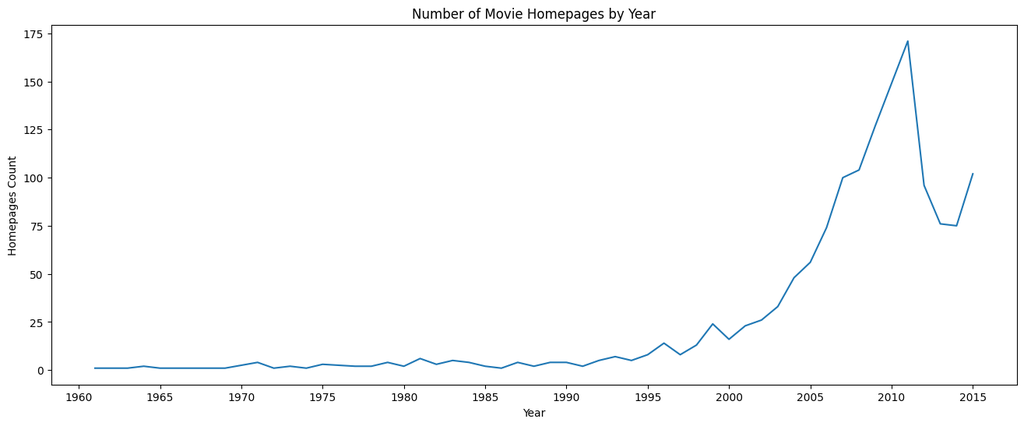

```python
homepage_df = df.dropna(subset='homepage')
homepages_by_year_df = homepage_df.groupby('release_year').homepage.count().to_frame()

plt.figure(figsize=(16, 6))
plt.xticks(np.arange(df.release_year.min(), df.release_year.max()+1, 5))
display_lineplot(homepages_by_year_df, None, None, 'Year', 'Homepages Count', 'Number of Movie Homepages by Year', legend=False)
```

> It appears that after the year 2004, movie homepages started to become increasingly popular. It is safe to assume that homepages were made for popular movies made prior to 1993, when the Internet became available for the public.

> Interestingly, there are homepages for movies prior to 1993. This suggests homepages were created for movies after they were released.

```python
df.query('original_title == "Star Wars"')[['original_title', 'release_year', 'homepage']]
```

|  | original_title | release_year | homepage |
| --- | --- | --- | --- |
| 1329 | Star Wars | 1977 | http://www.starwars.com/films/star-wars-episod... |

> Using Star Wars, a popular movie, investigating if it has a homepage that would have been created after its release.

> Verified the assumption that homepages were generated for movies released prior to 1993.

> Now that we have the counts of homepages by year, looking at the percentage of movies released by year to examine when movie homepages became popular.

```python
movies_by_year = df.groupby('release_year').id.count().to_frame()

movies_by_year.head()
```

| release_year | id |
| --- | --- |
| 1960 | 5 |
| 1961 | 10 |
| 1962 | 7 |
| 1963 | 6 |
| 1964 | 7 |

```python
homepages_by_year_df['percent_with_homepage'] = round((homepages_by_year_df.homepage / movies_by_year.id) * 100,2)
```

```python
homepages_by_year_df.reset_index(inplace=True)
```

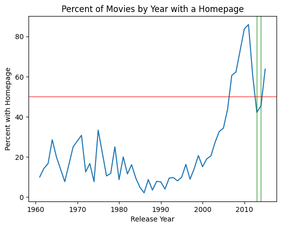

```python
release_yr_perc_homepage = homepages_by_year_df[['release_year', 'percent_with_homepage']].set_index('release_year')

display_lineplot(release_yr_perc_homepage, 'release_year', 'percent_with_homepage', 'Release Year', 'Percent with Homepage', 'Percent of Movies by Year with a Homepage', legend=False)
plt.axhline(50, color='red', alpha=0.5)
plt.axvline(2013, color='green', alpha=0.5)
plt.axvline(2014, color='green', alpha=0.5)
```

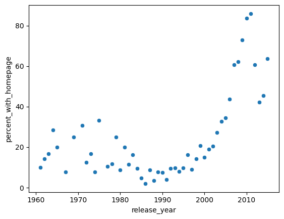

```python
sns.scatterplot(data=release_yr_perc_homepage, x="release_year", y="percent_with_homepage")
```

> As shown, movies made prior to 1993 (when the Internet became publicly available) have homepages. It is difficult to determine exactly when homepages started to become popoular. However, looking at the percentage of movies with homepages over time, it is reasonable to assume around 2005, movie homepages started to become popular. In 2011, approximately 86% of movies had a homepage before a sharp decline.

> Since 2006, at least 40% of the movies released have a homepage.

```python
df.vote_count.head()
```

```
0    5562
1    6185
2    2480
3    5292
4    2947
Name: vote_count, dtype: int64
```

> Graphing to see if there is a strong relationship between a movie's popularity and if it has a website.

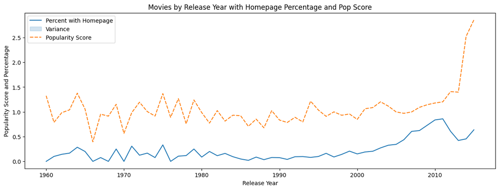

```python
homepage_popularity_by_year_df = df[["homepage", "popularity", "release_year"]]
homepage_popularity_by_year_df.loc[:, "has_homepage"] = np.where(homepage_popularity_by_year_df["homepage"].isnull() == False, True, False)
hp_pop_yr_grouped_df = homepage_popularity_by_year_df[["has_homepage", "popularity", "release_year"]].groupby('release_year').mean()

plt.figure(figsize=(15, 5))
display_lineplot(hp_pop_yr_grouped_df, None, None, 'Release Year', 'Popularity Score and Percentage', 'Movies by Release Year with Homepage Percentage and Pop Score', False)
plt.legend(labels=['Percent with Homepage', 'Variance',  'Popularity Score']);
```

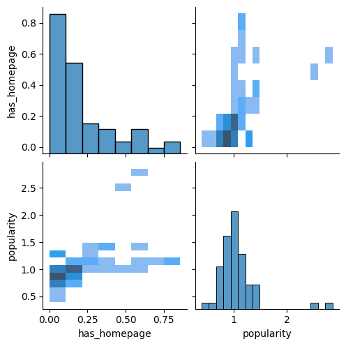

```python
sns.pairplot(hp_pop_yr_grouped_df, kind="hist")
```

### Research Question 2: Is there a average votes rating that is an indicator if a movie has a higher chance of being profitable?

```python
votes_profit_df = df[['vote_count', 'vote_average', 'release_year', 'profit_adj']]
```

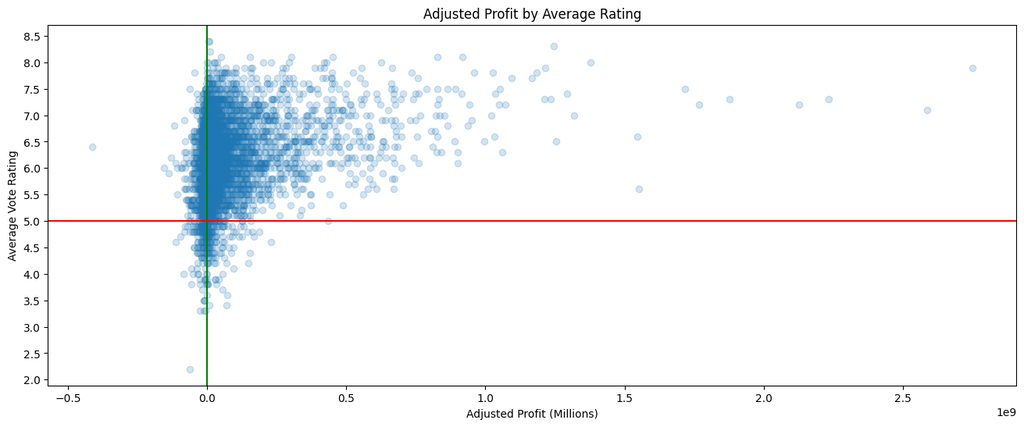

```python
plt.figure(figsize=(16,6))
plt.scatter(votes_profit_df['profit_adj'], votes_profit_df['vote_average'], alpha=0.2)
plt.xticks(np.arange(-500_000_000, 3_000_000_000, 500_000_000))
plt.yticks(np.arange(2,9,0.5))

plt.title('Adjusted Profit by Average Rating')
plt.xlabel('Adjusted Profit (Millions)')
plt.ylabel('Average Vote Rating')
plt.axvline(x=0, color='green')
plt.axhline(y=5, color='red')

plt.show()
```

> The scatter plot shows that around a 5.0 rating movies appear to have a higher chance at being profitable. However, there are so many data points around $0 that it is difficult to be for sure.

> Decided to group the ratings close to every 0.5

```python
votes_profit_df.loc[:, 'vote_avg_grouped'] = pd.cut(votes_profit_df.vote_average, np.arange(1.7, 9.2, 0.5), labels=[f'{i}' for i in np.arange(2, 9, 0.5)])
```

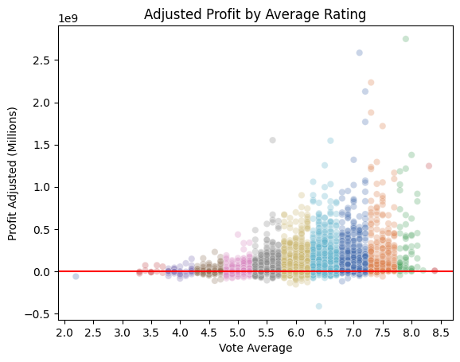

```python
g = sns.scatterplot(votes_profit_df, x='vote_average', y='profit_adj', hue='vote_avg_grouped', palette='deep', alpha=0.3, legend=False)
g.set_xticks(np.arange(2.0, 9, 0.5))
plt.axhline(y=0, color='red')
plt.title('Adjusted Profit by Average Rating')
plt.xlabel('Vote Average')
plt.ylabel('Profit Adjusted (Millions)')
```

> The graph above gives a slightly better picture of how a movie is generally more profitable as it receives an average rating above 5.0. However, to answer the original question, a line graph will be constructed to better identify the percentage of profitable movies by average rating.

```python
chance_profitable = df.query('profit_adj > 0 and budget_adj != 0 and revenue_adj != 0').count() / df.count()
chance_profitable[0]
```

```
0.7208095485210171
```

```python
above_rating_5_25_df = df.query('vote_average >= 5.25')
above_rating_5_25_df.query('profit_adj > 0').shape[0] / above_rating_5_25_df.shape[0]
```

```
0.7526595744680851
```

```python
above_rating_6_5_df = df.query('vote_average >= 6.5')
above_rating_6_5_df.query('profit_adj > 0').shape[0] / above_rating_6_5_df.shape[0]
```

```
0.8253094910591472
```

> Having a movie rated 5.25 or greater increases it's chance to be profitable by approximately 3%. Having a movie rated 6.5 or greater increases it's chance to be profitable by approximately 10%.

```python
votes_profit_df.loc[:, 'profitable'] = np.where(votes_profit_df['profit_adj'] > 0, 1, 0)
```

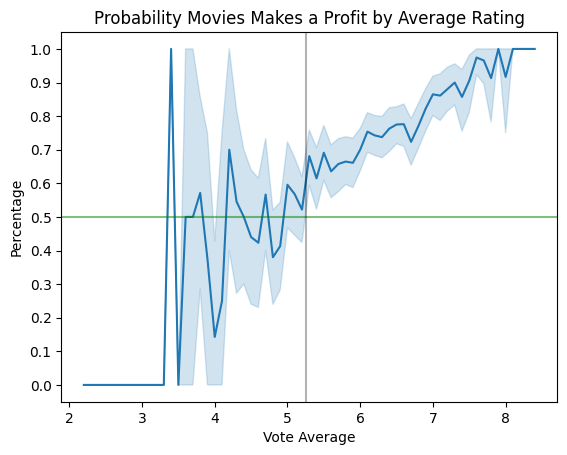

```python
display_lineplot(votes_profit_df, 'vote_average', 'profitable', 'Vote Average', 'Percentage', 'Probability Movies Makes a Profit by Average Rating')
plt.yticks(np.arange(0, 1.01, 0.1))
plt.axhline(y=0.5, color='green', alpha=0.5)
plt.axvline(x=5.25, color='black', alpha=0.3);
```

> It appears if a movie is rated 8.1 or higher, it is guaranteed to be higher. Investigating which movie was rated 8.0 and was not profitable.

```python
above_rating_8_df = df.query('vote_average >= 8.0')
above_rating_8_df.query('profit_adj > 0').shape[0] / above_rating_8_df.shape[0]
```

```
0.9545454545454546
```

```python
above_rating_8_df.query('profit_adj < 0')
```

|  | id | popularity | original_title | cast | homepage | director | keywords | overview | runtime | genres | production_companies | release_date | vote_count | vote_average | release_year | budget_adj | revenue_adj | profit_adj |
| --- | --- | --- | --- | --- | --- | --- | --- | --- | --- | --- | --- | --- | --- | --- | --- | --- | --- | --- |
| 718 | 265177 | 1.737699 | Mommy | Anne Dorval\|Suzanne Clément\|Antoine-Olivier P... | NaN | Xavier Dolan | quebec\|dysfunctional family\|single mother\|moth... | A peculiar neighbor offers hope to a recent wi... | 138 | Drama | Téléfilm Canada\|Super Écran\|SODEC\|Metafilms | 5/22/14 | 389 | 8.0 | 2014 | 4.513346e+06 | 3.218357e+06 | -1.294990e+06 |

> The highest rated movie that was not profitable was rated an 8.0 in 2014.

## Research Question 3: What are the most common genres?

```python
genres_df.describe()
```

|  | genre |
| --- | --- |
| count | 10303 |
| unique | 20 |
| top | Drama |
| freq | 1756 |

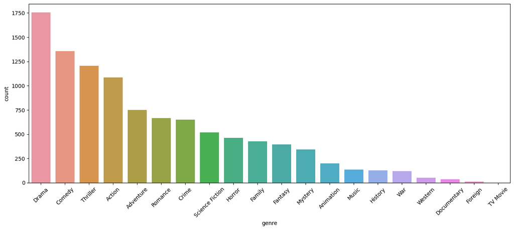

```python
plt.figure(figsize=(16, 6))
sns.countplot(genres_df, x='genre', order=genres_df['genre'].value_counts().index)
plt.xticks(rotation=45);
```

## Conclusions

Original Questions

## Question 1: What year did homepages for movies start to become popular?

One limitation of the data was not knowing if the homepages were created after the release of the movie. In order to fully answer the question, a field storing the creation date of the homepage would be needed.

## Question 2: Is there a average votes rating that is an indicator if a movie has a higher chance of being profitable?

When a movie is released, there is about a 72% chance it will be profitable. The ratings appear to be an indicator if it will or will not be profitable. It appears if a movie is rated 5.25 or higher, it is at least 50% likely to be profitable. A movie rated 6.5+ has over an 82% chance of being profitable.

A limitation of this analysis is the missing budget and revenue data. There were many zero values that could improve the analysis.

## Question 3: What are the msot common genres?

> The top 3 most common genres are Drama, Comedy, and Thriller.

```python
# Running this cell will execute a bash command to convert this notebook to an .html file
!python -m nbconvert --to html Investigate_a_Dataset.ipynb
```

```
[NbConvertApp] Converting notebook Investigate_a_Dataset.ipynb to html
[NbConvertApp] Writing 1373504 bytes to Investigate_a_Dataset.html
```